# Machine learning using RBM

kuldeep singh bhati

The project is about to train indicators input to a RBM.We are predicting that next bar of euro dollar will be up or down. After predicting we are testing on next 1000 bars. We have used darch package for training RBM.

## Euro/dollar data taken from 2007 to 2016 26 minute data

```r
set.seed(2)
price<-read.table("euro.txt",header=TRUE,sep=",")
price<-subset(price[,3:6])
```

Median price of high and low

```r
Med <- (price[,2] + price[,3])/2
CO <- price[, 4] - price[, 1]
```

Add Med and CO prices to the matrix

```r
price <- cbind(price, Med, CO)
```

## First generate input signals from indicator to train

```r
Input<- function(p = 14){

    adx <- ADX(price, n = p) %>% as.data.frame %>%
    mutate(.,oscDX = DIp - DIn) %>%
    transmute(.,DX, ADX, oscDX) %>%
    as.matrix()
  ar <- aroon(price[ ,c('High', 'Low')], n = p) %>% extract(,3)
  atr <- ATR(price, n = p, maType = "EMA") %>% extract(,1:2)
  cci <- CCI(price[ ,2:4], n = p)
  chv <- chaikinVolatility(price[ ,2:4], n = p)
  cmo <- CMO(price[ ,'Med'], n = p)
  macd <- MACD(price[ ,'Med'], 12, 26, 9) %>% as.data.frame() %>% mutate(., vsig = signal %>%
             diff %>% c(NA,.) %>% multiply_by(10)) %>% transmute(., sign = signal, vsig) %>% as.matrix()
  rsi <- RSI(price[ ,'Med'], n = p)
  stoh <- stoch(price[ ,2:4], nFastK = p, nFastD =3, nSlowD = 5, maType = "EMA") %>%
                                as.data.frame() %>%
                                mutate(., oscK = fastK - fastD) %>%
                                transmute(.,slowD, oscK) %>%
                                as.matrix()
  smi <- SMI(price[ ,2:4],n = p, nFast = 2, nSlow = 25, nSig = 9)
  kst <- KST(price[ ,4])%>% as.data.frame() %>% mutate(., oscKST = kst - signal) %>%
                                transmute(.,oscKST) %>% as.matrix()
  xavg<-EMA(price[,2],n=14)
  trend<-price[,2]-xavg
  Input <- cbind(adx, ar, atr, cci, chv, cmo, macd,
              rsi, stoh, smi, kst,xavg,trend)
  return(Input)
}
```

### As a target variable we take signals obtained with ZZ. The function calculating a zigzag and a signal:

```r
ZZ <- function(pr = price, ch = ch , mode="m") {
  if (ch > 1) ch <- ch/(10 ^ (5 - 1))
  if (mode == "m") {pr <- pr[ ,'Med']}
  zz <- ZigZag(pr, change = ch, percent = F,
               retrace = F, lastExtreme = T)
  n <- 1:length(zz)
  dz <- zz %>% diff %>% c(., NA)
  sig <- sign(dz)
  for (i in n) { if (is.na(zz[i])) zz[i] = zz[i - 1]}
  return(cbind(zz, sig))
}
```

The function returns the matrix with two variables - in fact, the zigzag and the signal,obtained on the base of the zigzag angle in the range of [-1;1].We shift the signal by one bar to the left (towards future).

```r
out <- ZZ(ch = 37, mode = "m")
table(out[ ,2])
```

```
##
##    -1     1
## 23684 24124
```

## Initialize data frame

Let’s write a function that will create the initial data frame, clean it from uncertain data (NA) and convert the target variable to the factor with two classes “-1” and “+1”. This function combines previously written functions Input() and ZZ(). We will instantly crop the last 1000 bars that will be used to evaluate the quality of the model’s prediction.

### This specific signal will be used to train the neural network.

```r
form.data <- function(n = 14, z = 37, len = 1000){
  x <- Input(p = n)
  out <- ZZ(ch = z, mode = "m")
  data <- cbind(x, y = out[ ,2]) %>%
    as.data.frame %>% head(., (nrow(x)-len))%>%na.omit
  data$y <- as.factor(data$y)
  return(data)
}
```

### Deleting highly correlated variables

We will delete variables with a correlation coefficient above 0.9 from our initial set. We will write a function that will form the initial data frame, remove highly correlated variables and return clean data.

```r
data <- form.data(n = 14, z = 37)
descCor <- cor(data[ ,-ncol(data)])
summary(descCor[upper.tri(descCor)])
```

```
##     Min.  1st Qu.   Median     Mean  3rd Qu.     Max.
## -0.20530  0.04353  0.19990  0.29830  0.60910  0.95420
```

```r
highCor <-findCorrelation(descCor, cutoff = 0.9)
highCor
```

```
## [1] 12 13 15
```

```r
colnames(data[ ,highCor])
```

```
## [1] "rsi"   "slowD" "SMI"
```

```r
data.f <- data[,-highCor]
```

### Selection of the most important variables

Important variables will be selected based on three indicators: global importance, local importance (in conjunction) and partial importance by class.Once executed, we will obtain three sets as a result:

with best variables in contribution and interaction; with best variables for the class “-1” with best variables for the class “+1”.

### Divide the data into test and validation data

```r
inTrain<-createDataPartition(y = data.f$y, p = 0.8, list = FALSE)
training<-data.f[inTrain,]
validation<-data.f[-inTrain,]
```

### Preprocess the data. determine pre-processing parameters and normalized input data.

```r
preProc<- preProcess(training[, -17], method = c("center", "scale","spatialSign"))
trainPC<-predict(preProc,training[,-17])
validPC<-predict(preProc,validation[,-17])
modelFit<-randomUniformForest(training$y~.,data=trainPC,importance=TRUE,mtry=1,ntree=300,threads=2,nodesize=1)
```

```
## Labels -1 1 have been converted to 1 2 for ease of computation and will be used internally as a replacement.
```

```r
print(modelFit)
```

```
## Call:
## randomUniformForest.formula(formula = training$y ~ ., data = trainPC,
##     importance = TRUE, mtry = 1, ntree = 300, threads = 2, nodesize = 1)
##
## Type of random uniform forest: Classification
##
##                            paramsObject
## ntree                               300
## mtry                                  1
## nodesize                              1
## maxnodes                            Inf
## replace                            TRUE
## bagging                           FALSE
## depth                               Inf
## depthcontrol                      FALSE
## OOB                                TRUE
## importance                         TRUE
## subsamplerate                         1
## classwt                           FALSE
## classcutoff                       FALSE
## oversampling                      FALSE
## outputperturbationsampling        FALSE
## targetclass                          -1
## rebalancedsampling                FALSE
## randomcombination                 FALSE
## randomfeature                     FALSE
## categorical variables             FALSE
## featureselectionrule            entropy
##
## Out-of-bag (OOB) evaluation
## OOB estimate of error rate: 29.89%
## OOB error rate bound (with 1% deviation): 30.31%
##
## OOB confusion matrix:
##           Reference
## Prediction    -1     1 class.error
##         -1 13068  5686      0.3032
##         1   5496 13158      0.2946
##
## OOB estimate of AUC: 0.7011
## OOB estimate of AUPR: 0.7037
## OOB estimate of F1-score: 0.7018
## OOB (adjusted) estimate of geometric mean: 0.7011
##
## Breiman's bounds
## Expected prediction error (under approximatively balanced classes): 14.7%
## Upper bound: 23.27%
## Average correlation between trees: 0.0433
## Strength (margin): 0.4771
## Standard deviation of strength: 0.2302
```

### select 10 most important variables in terms of contribution and interaction - best:

```r
imp.modelFit<-importance(modelFit,Xtest=validPC)
```

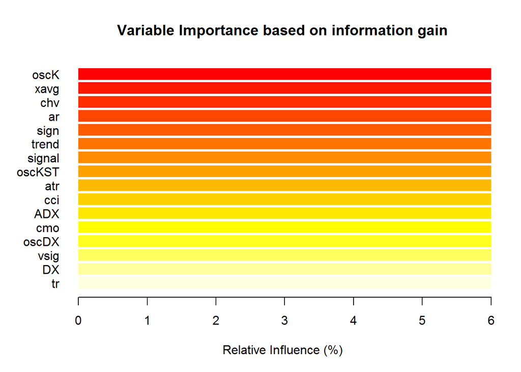

```
##
## 1 - Global Variable Importance (16 most important based on information gain) :
## Note: most predictive features are ordered by 'score' and plotted. Most discriminant ones
## should also be taken into account by looking 'class' and 'class.frequency'.
##
##    variables score class class.frequency percent percent.importance
## 1       oscK 20988     1            0.50  100.00                  6
## 2       xavg 20922    -1            0.50   99.69                  6
## 3        chv 20890     1            0.50   99.54                  6
## 4         ar 20888     1            0.50   99.52                  6
## 5       sign 20731     1            0.50   98.78                  6
## 6      trend 20714     1            0.51   98.70                  6
## 7     signal 20648     1            0.50   98.38                  6
## 8     oscKST 20630     1            0.50   98.29                  6
## 9        atr 20614     1            0.50   98.22                  6
## 10       cci 20611     1            0.50   98.21                  6
## 11       ADX 20607     1            0.50   98.19                  6
## 12       cmo 20578    -1            0.50   98.05                  6
## 13     oscDX 20575     1            0.50   98.03                  6
## 14      vsig 20518    -1            0.50   97.76                  6
## 15        DX 20417     1            0.50   97.28                  6
## 16        tr 20203     1            0.51   96.26                  6
##
##
## 2 - Local Variable importance
## Variables interactions (10 most important variables at first (columns) and second (rows) order) :
## For each variable (at each order), its interaction with others is computed.
##
##                 cci     DX  trend    atr   oscK  oscDX   vsig    cmo
## cci          0.2932 0.1672 0.1671 0.1437 0.1203 0.1086 0.1068 0.1051
## DX           0.2897 0.1636 0.1636 0.1401 0.1168 0.1050 0.1032 0.1015
## trend        0.2760 0.1499 0.1499 0.1265 0.1031 0.0913 0.0895 0.0879
## atr          0.2533 0.1272 0.1272 0.1037 0.0804 0.0686 0.0668 0.0651
## oscK         0.2467 0.1206 0.1206 0.0972 0.0738 0.0620 0.0602 0.0586
## oscDX        0.2317 0.1056 0.1056 0.0821 0.0588 0.0470 0.0452 0.0435
## tr           0.2314 0.1054 0.1053 0.0819 0.0585 0.0467 0.0449 0.0433
## vsig         0.2313 0.1052 0.1052 0.0818 0.0584 0.0466 0.0448 0.0432
## cmo          0.2295 0.1035 0.1034 0.0800 0.0566 0.0449 0.0431 0.0414
## oscKST       0.2213 0.0953 0.0952 0.0718 0.0484 0.0367 0.0349 0.0332
## avg1rstOrder 0.2363 0.1103 0.1102 0.0868 0.0634 0.0517 0.0499 0.0482
```

[output cut: 36 more lines]

```
## oscK       0.04    0.07
## vsig       0.05    0.01
## oscDX      0.03    0.04
## cmo        0.02    0.04
## tr         0.03    0.02
## oscKST     0.02    0.02
##
##
## See ...$localVariableImportance$obsVariableImportance to get variable importance for each observation.
##
## Call clusterAnalysis() function to get a more compact and complementary analysis.
##  Type '?clusterAnalysis' for help.
##
## Call partialDependenceOverResponses() function to get partial dependence over responses
## for each variable. Type '?partialDependenceOverResponses' for help.
```

Best parameters with best sell and best buy

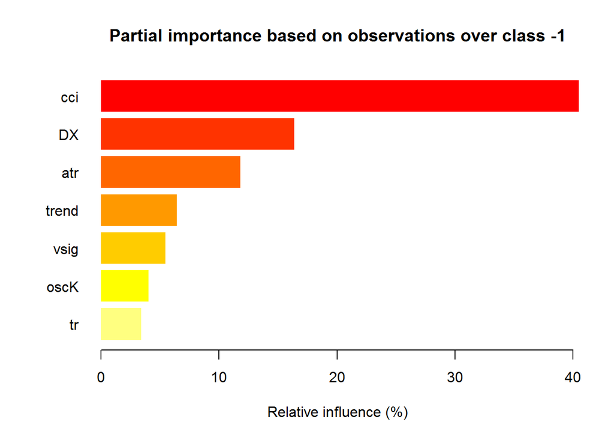

```
## Relative influence: 87.96%
```

```r
best <- imp.modelFit$localVariableImportance$classVariableImportance %>% head(., 10) %>% rownames()

best.sell <- partialImportance(X = validPC,imp.modelFit,whichClass = "-1",nLocalFeatures = 7) %>% row.names() %>%
as.numeric() %>% colnames(validPC)[.]
```

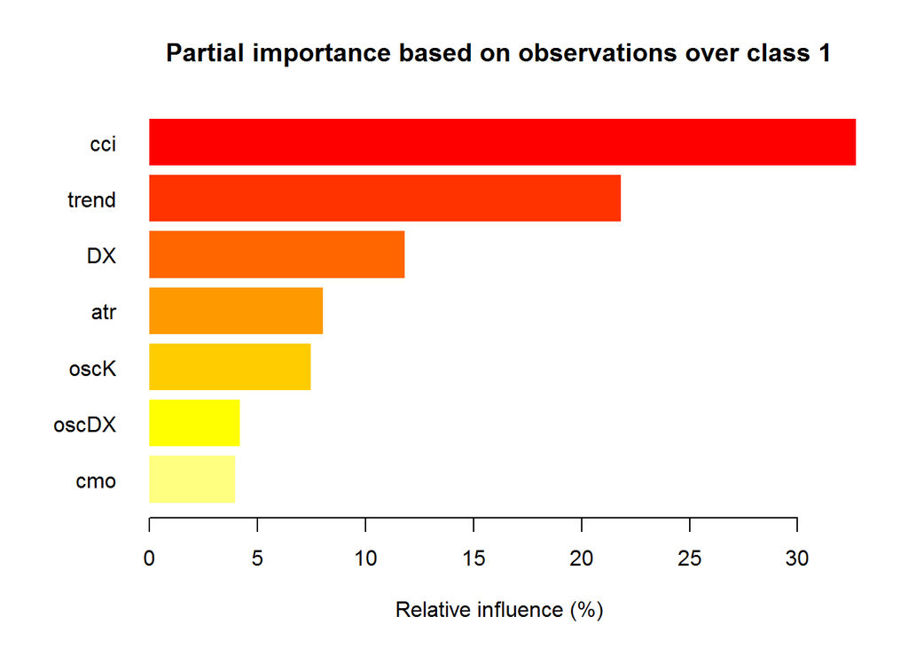

```
## Relative influence: 89.99%
```

```r
best.buy <- partialImportance(X = validPC,imp.modelFit,whichClass = "1",nLocalFeatures = 7) %>% row.names() %>%
as.numeric() %>% colnames(validPC)[.]
```

### Create a list with three sets of predictors - best, best.buy, best.sell.

```r
dt <- list(best = best, buy = best.buy, sell = best.sell)
```

## Now selecting the best parameters for training using RBM.

subsetting all of the best parameters

```r
datat<-data.f[,best]
y<-data.f[,17]
data.b<-cbind(datat,y)
head(data.b,2)
```

```
##            cci         trend        DX          atr       oscK        vsig
## 53 -54.5137070 -0.0008096755  6.140291 0.0007130441 0.02211386 -0.01696777
## 54  -0.5982906 -0.0002683854 13.523893 0.0007246382 0.05867598 -0.01118929
##        oscDX       cmo    tr     oscKST y
## 53  5.246813 -28.57143 4e-04 -0.3940947 1
## 54 11.430743 -18.47134 8e-04 -0.3364881 1
```

```r
x<-data.b[ ,-ncol(data.b)]
y<-data.b[ , ncol(data.b)]
```

## Now do stratified random division for the best data

```r
t <- holdout(y = y, ratio = 0.8,mode = "stratified")
train <- cbind(x[t$tr, ], y = y[t$tr])
```

## Now do rebalancing for train data to get the best output. balancing makes 0,1 equal for output y.

```r
Balancing<-function(DT){
  #Calculate a table with a number of classes
  cl<-table(DT[ ,ncol(DT)]);
  #If the divergence is less than 15%, return the initial matrix
  if(max(cl)/min(cl)<= 1.15) return(DT)
  #Otherwise level by the greater side
  DT<-if(max(cl)/min(cl)> 1.15){
         upSample(x = DT[ ,-ncol(DT)],y = as.factor(DT[ , ncol(DT)]), yname = "Y")
        }
  #Convert ? (factor) into a number
  DT$Y<-as.numeric(DT$Y)
  #Recode ? from 1,2 into 0,1
  DT$Y<-ifelse(DT$Y == 1, 0, 1)
  #Convert dataframe to matrix
  DT<-as.matrix(DT)
  return(DT);
}
```

### To run the above program we have to use.

```r
trainb<-Balancing(train)
test <- cbind(x[t$ts, ], y = y[t$ts])
```

## Now preprocess the data for training neural network

```r
prepr<-preProcess(trainb[ ,best], method = "spatialSign")
train = predict(prepr, trainb[ ,best])%>% cbind(., y = trainb$y)
test =  predict(prepr, test[ ,best] %>% cbind(., y = test$y))
DT <- list(train = train,test = test)
```

First, we create the deep architecture object named DArch, that includes the required number of RBM with parameters of preliminary training by default, and the neural network initiated with random weights and neuron activation function set by default.

```r
y <- DT$train$y %>% classvec2classmat()
```

### create dataSet for training

```r
darch <- darch(DT$train[ ,best] %>% as.matrix(), y, c(10,20,2), rbm.batchSize = 50, rbm.numEpochs =100, darch.numEpochs = 0)
```

[output not shown]

[output cut: 154 more lines]

[output not shown]

### testing accuracy of the system

```r
testAcc <- function(obj, typ = "bin")
{
  x.ts <- DT$test[ ,best] %>% as.matrix()
  y.ts <- DT$test$y %>% as.integer() %>% subtract(1)
  out <- predict(obj, newdata = x.ts, type = typ)
  out <- max.col(out)-1
  acc <- length(y.ts[y.ts == out])/length(y.ts) %>% round(., digits = 4)
  return(list(Acc = acc, y.ts = y.ts, y = out))
}
```

### Accuracy value on test data

```r
yt<-testAcc(darch)
yt$Acc
```

```
## [1] 0.5018178
```

### Preparing the test for last 1000 bars for testing the strategy

```r
prepareTest <- function(n, z, norm, len = 1000)
{
  x <- Input(p = n ) %>% na.omit %>% extract( ,best) %>% tail(., len)
  CO <- price[ ,"CO"] %>% tail(., len)
  if (norm) {
    x <- predict(prepr,x)
  }
  dt <- cbind(x = x, CO = CO) %>% as.data.frame()
  return(dt)
}
```

### Preparing data for the test

```r
DT.test <- prepareTest(n = 14, z = 37, T)
testBal <- function(obj, typ = "bin") {
  require(fTrading)
  x <- DT.test[,best]
  CO <- DT.test$CO
  out <- predict(obj, newdata = x, type = typ)
  out <- max.col(out)-1
  sig <- ifelse(out == 0, -1, 1)
  sig1 <- Hmisc::Lag(sig) %>% na.omit
  bal <- cumsum(sig1 * tail(CO, length(sig1)))
  K <- tail(bal, 1)/length(bal) * 10 ^ 4
  Kmax <- max(bal)/which.max(bal) * 10 ^ 4
  dd <- maxDrawDown(bal)
  return(list(sig = sig, bal = bal, K = K,Kmax = Kmax, dd = dd))
}
```

```r
lt<-testBal(darch)
```

[output not shown]

[output not shown]

[output not shown]

[output not shown]

[output not shown]

[output not shown]

```r
bal<-lt$bal
# signal on the last 1000 bars
sig <- lt$sig[1:1000]
# average from the balance line
ma <-movavg(bal,16, "t")
# momentum from the average
roc <-momentum(ma, 3)%>% na.omit
# balance line deviation from the average
dbal <- (bal - ma) %>% tail(., length(roc))
# summarize two vectors
dbr <- (roc + dbal) %>% as.matrix()
# calculate correction signal
sig.cor <- ifelse(dbr > 0, 1, -1)
# resulting signal
S <- sig.cor * tail(sig, length(sig.cor))
# balance on resulting signal
Bal <- cumsum(S * (price[ ,"CO"]%>% tail(.,length(S))))
# quality coefficient on the corrected signal
Kk <- tail(Bal, 1)/length(Bal) * 10 ^ 4
```

### Ploting the corrected balance

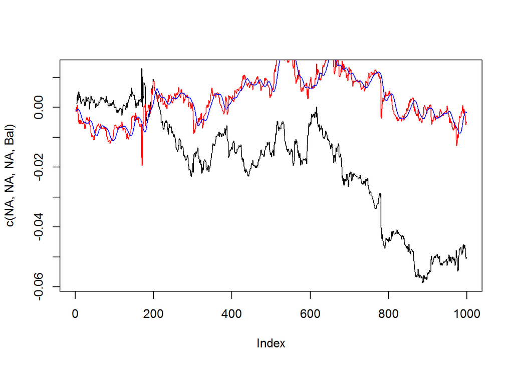

```r
plot(c(NA,NA,NA,Bal), t="l")
lines(bal, col= 2)
lines(ma, col= 4)
```